# STA 141B HW 1

Vincent Barletta

2023-04-10

## Introduction

This is an exercise in reading in unconventional data tables and learning how to transform the tables into a more readable, usable format to get immediate insights from weather data across multiple geographical areas.

#### .wea files

First, we will begin with the .wea files. These are debatably the easiest to begin with, and provide us with some basic data.

```r
path_sf = "C:/Users/HP/Documents/141BProject1Files/USA_CA_Fairfield-San.Francisco.Bay.Reserve.998011_TMYx.2007-2021.wea"
path_marin = "C:/Users/HP/Documents/141BProject1Files/USA_CA_Marin.County.AP-Gnoss.Field.720406_TMYx.2007-2021.wea"
path_napa = "C:/Users/HP/Documents/141BProject1Files/USA_CA_Napa.County.AP.724955_TMYx.2007-2021.wea"
path_davis = "C:/Users/HP/Documents/141BProject1Files/USA_CA_UC-Davis-University.AP.720576_TMYx.2007-2021.wea"
path_reyes = "C:/Users/HP/Documents/141BProject1Files/USA_CA_Point.Reyes.Lighthouse.724959_TMYx.2007-2021.wea"

#According to Piazza, the .wea and .pvsyst files should have two seperate dataframes and .stat will have 9 different tables.

# We will start by reading in the first 6 lines which provides the metadata for the table.

#Table 1 - Metadata


weather_metadata <- function(path) {

  table_name <- readLines(path, n = 6)
  place <- substring(table_name[1], nchar("place") + 2)
  latitude <- as.numeric(substring(table_name[2], nchar("laditude") + 2))
  longitude <- as.numeric(substring(table_name[3], nchar("longitude") + 2))
  time_zone <- as.numeric(substring(table_name[4], nchar("time_zone") + 2))
  site_elevation <- as.numeric(substring(table_name[5], nchar("site_elevation") + 2))
  weather_data_file_units <- as.numeric(substring(table_name[6], nchar("weather_data_file_units") + 2))

  table_name <- data.frame(place, latitude, longitude, time_zone, site_elevation, weather_data_file_units)
}

sf_wea_meta <- weather_metadata(path_sf)
marin_wea_meta <- weather_metadata(path_marin)
napa_wea_meta <- weather_metadata(path_napa)
davis_wea_meta <- weather_metadata(path_davis)
pr_wea_meta <- weather_metadata(path_reyes)

#After creating the last function, I realized table_name does not matter as the assigned name is created after we call the function and save it.

weather_data <- function(path) {
  table <- read.table(path, header = FALSE, sep = " ", skip = 6)
  wea_column_names <- c("month", "day", "standard time", "direct normal irradiance", "diffuse horizontal irradiance")
  colnames(table) <- wea_column_names
  return(table)
}

fairfield_wea <-weather_data(path_sf)
marin_wea_meta <- weather_metadata(path_marin)
napa_wea <- weather_metadata(path_napa)
davis_wea <- weather_metadata(path_davis)
pr_wea <- weather_metadata(path_reyes)
```

## PVSyst

Let’s start with the metadata. We can skip the first three lines as they provide no data.

```r
path_sf = "C:/Users/HP/Documents/141BProject1Files/USA_CA_Fairfield-San.Francisco.Bay.Reserve.998011_TMYx.2007-2021.pvsyst"
path_marin = "C:/Users/HP/Documents/141BProject1Files/USA_CA_Marin.County.AP-Gnoss.Field.720406_TMYx.2007-2021.pvsyst"
path_napa = "C:/Users/HP/Documents/141BProject1Files/USA_CA_Napa.County.AP.724955_TMYx.2007-2021.pvsyst"
path_davis = "C:/Users/HP/Documents/141BProject1Files/USA_CA_UC-Davis-University.AP.720576_TMYx.2007-2021.pvsyst"
path_reyes = "C:/Users/HP/Documents/141BProject1Files/USA_CA_Point.Reyes.Lighthouse.724959_TMYx.2007-2021.pvsyst"

 pv_metatable <- function(path) {
    file_lines <- readLines(path, n = 12)
    file_lines <- file_lines[4:12]
    file_lines <- file_lines[-4]
    split <- strsplit(file_lines, ",")

  #We want to get rid of all of the # in front of our data values
  for(i in seq_along(split)) {
    split[[i]][1] <- gsub("#", "", split[[i]][1])
  }

  #I couldn't find a good way to split the string directly, so we take two substrings and then split the value from the name using strsplit

  WMO<- substring(split[[1]],1,10)
  DataSource<- substring(split[[1]],11)

  split[[9]] <- strsplit(DataSource, "=")
  split[[1]] <- strsplit(WMO, "=")

  split <- split[1:9]
  metadata_table_pv <- data.frame(split)
  #I tried numerous times to try and get the indexing correct so that the df_list would only take the second element of each part of the nested list and to use the first element as the name. Unfortunately, I was unable to do this.

  #Therefore, we will keep the names, and simply scrap the first row from the table.
  names(metadata_table_pv) <- metadata_table_pv[1,]
  metadata_table_pv <- metadata_table_pv[2,]
  metadata_table_pv
 }

sf_pvsyst_metadata <- pv_metatable(path_sf)
head(sf_pvsyst_metadata)
```

```
##      WMO                                Site Country Time step Latitude
## 2 998011 Fairfield-San.Francisco.Bay.Reserve     USA      Hour   38.200
##   Longitude Altitude Time Zone Data Source
## 2  -122.026        4     -8.00    SRC-TMYx
```

```r
marin_pvsyst_metadata <- pv_metatable(path_marin)
head(marin_pvsyst_metadata)
```

```
##      WMO                        Site Country Time step Latitude Longitude
## 2 720406 Marin.County.AP-Gnoss.Field     USA      Hour   38.150  -122.550
##   Altitude Time Zone Data Source
## 2        1     -8.00    SRC-TMYx
```

```r
davis_pvsyst_metadata <- pv_metatable(path_davis)
davis_pvsyst_metadata
```

```
##      WMO                   Site Country Time step Latitude Longitude Altitude
## 2 720576 UC-Davis-University.AP     USA      Hour   38.533  -121.783       21
##   Time Zone Data Source
## 2     -8.00    SRC-TMYx
```

```r
pointreyes_pvsyst_metadata <- pv_metatable(path_reyes)
pointreyes_pvsyst_metadata
```

```
##      WMO                   Site Country Time step Latitude Longitude Altitude
## 2 724959 Point.Reyes.Lighthouse     USA      Hour   37.996  -123.023       87
##   Time Zone Data Source
## 2     -8.00    SRC-TMYx
```

```r
napa_pvsyst_metadata <- pv_metatable(path_napa)
napa_pvsyst_metadata
```

```
##      WMO           Site Country Time step Latitude Longitude Altitude Time Zone
## 2 724955 Napa.County.AP     USA      Hour   38.210  -122.285       11     -8.00
##   Data Source
## 2    SRC-TMYx
```

```r
#Now, for the actual data...

pvsyst_table <- function(path) {
  ll = readLines(path)[-c(1:12,14)]
  con = textConnection(ll)
  table <- read.table(con, header = TRUE, sep = ",")
  return(table)
}

sf_pvsyst_data <- pvsyst_table(path_sf)
head(sf_pvsyst_data)
```

```
##   Year Month Day Hour Minute GHI DHI DNI Tamb WindVel WindDir
## 1 2059     1   1    1     30   0   0   0    5       4      90
## 2 2059     1   1    2     30   0   0   0    4       4      40
## 3 2059     1   1    3     30   0   0   0    3       5      70
## 4 2059     1   1    4     30   0   0   0    1       2      40
## 5 2059     1   1    5     30   0   0   0    1       3      80
## 6 2059     1   1    6     30   0   0   0    1       3      70
```

```r
marin_pvsyst_data <- pvsyst_table(path_marin)
head(marin_pvsyst_data)
```

```
##   Year Month Day Hour Minute GHI DHI DNI Tamb WindVel WindDir
## 1 2059     1   1    1     30   0   0   0    7       0     316
## 2 2059     1   1    2     30   0   0   0    5       2     170
## 3 2059     1   1    3     30   0   0   0    4       0     349
## 4 2059     1   1    4     30   0   0   0    5       2     190
## 5 2059     1   1    5     30   0   0   0    2       0      80
## 6 2059     1   1    6     30   0   0   0    2       0      98
```

```r
davis_pvsyst_data <- pvsyst_table(path_davis)
head(davis_pvsyst_data)
```

```
##   Year Month Day Hour Minute GHI DHI DNI Tamb WindVel WindDir
## 1 2059     1   1    1     30   0   0   0    4       5     350
## 2 2059     1   1    2     30   0   0   0    4       5     340
## 3 2059     1   1    3     30   0   0   0    4       6     340
## 4 2059     1   1    4     30   0   0   0    5       7     340
## 5 2059     1   1    5     30   0   0   0    5       6     340
## 6 2059     1   1    6     30   0   0   0    5       8     340
```

```r
pointreyes_pvsyst_data <- pvsyst_table(path_reyes)
head(pointreyes_pvsyst_data)
```

```
##   Year Month Day Hour Minute GHI DHI DNI Tamb WindVel WindDir
## 1 2059     1   1    1     30   0   0   0   12       3     350
## 2 2059     1   1    2     30   0   0   0   12       3      10
## 3 2059     1   1    3     30   0   0   0   12       2     280
## 4 2059     1   1    4     30   0   0   0   13       3      40
## 5 2059     1   1    5     30   0   0   0   14       6      80
## 6 2059     1   1    6     30   0   0   0   14       2      30
```

```r
napa_pvsyst_data <- pvsyst_table(path_napa)
head(napa_pvsyst_data)
```

```
##   Year Month Day Hour Minute GHI DHI DNI Tamb WindVel WindDir
## 1 2059     1   1    1     30   0   0   0    9       4     240
## 2 2059     1   1    2     30   0   0   0   10       3     220
## 3 2059     1   1    3     30   0   0   0    7       3      20
## 4 2059     1   1    4     30   0   0   0    4       3     330
## 5 2059     1   1    5     30   0   0   0    3       0     236
## 6 2059     1   1    6     30   0   0   0    3       2     300
```

## STAT Files

#### Table Generation

```r
dir = "C:/Users/HP/Documents/141BProject1Files"
path = file.path(dir, "USA_CA_Fairfield-San.Francisco.Bay.Reserve.998011_TMYx.2007-2021.stat")

#Reads in all of the tables
#Next: needs to make adjustments to tables

stat_table <- function(start_name, end_name = "Daily Avg", colname = "Statistic", type = "monthly", path = path) {

  master = readLines(path)

  start = grep(start_name, master)

  if(type == "hourly") {

    #We use grep to find all the occurences of "Min Hour" in our master document. We then see of all of these occurences, which one of them have a value greater than the line where the table starts. Then, we use the min function to find the smallest of these occurences, as that would be the logical ending point. Lastly, we use this to index the grep function.

    end = grep("Min Hour", master)[min(which(grep("Min Hour", master) > start))]
    colname = "Hour"
  }

  else {
    end = grep(end_name, master)[min(which(grep(end_name, master) > start))]
  }

  # We read in the table up until the last line of the table we need, and then subset out lines 1-Starting value so that we only get the part of the dataset that we need

  ll = readLines(path, n=end)[-(1:start)]
  con = textConnection(ll)
  table <- read.table(con, header = TRUE, sep = "\t")[-c(1,15)]
  colnames(table)[1] <- colname
  table

}

hourly_bulb <- stat_table(start_name = "Average Hourly Statistics for Dry Bulb temperatures", type = "hourly", path = path)
hourly_dewpoint <- stat_table(start_name = "Average Hourly Statistics for Dew Point temperatures", type = "hourly" , path = path)
hourly_humidity <- stat_table(start_name = "Average Hourly Relative Humidity", type = "hourly" , path = path)
hourly_solar <- stat_table(start_name = "Average Hourly Statistics for Direct Normal Solar Radiation", type = "hourly" , path = path)
hourly_windspeed <- stat_table(start_name = "Average Hourly Statistics for Wind Speed", type = "hourly" , path = path)

monthly_wind <- stat_table(start_name = "Monthly Wind Direction", end_name = "NNW", colname = "Direction" , path = path)
monthly_drybulb <- stat_table(start_name = "Monthly Statistics for Dry Bulb temperatures", end_name = "NightTime Avg" , path = path)
monthly_dewpoint <- stat_table(start_name = "Monthly Statistics for Dew Point temperatures" , path = path)
monthly_windspeed <- stat_table(start_name = "Monthly Statistics for Wind Speed" , path = path)
```

#### Monthly Table Transformations

```r
#Transposing Monthly List

monthly_transformations <- function(table) {

  df = data.frame(t(table))
  colnames(df) = df[1,]
  df = df[-1,]
  rownames <- rownames(df)

   #if argument suggested by ChatGPT; it takes the name of the passed in value, deparses it, and checks if it matches to monthly_wind
   # This is done to scrape the table name passed in; I did not know a better way to do it. In this case, we only want the the monthly_wind table as it is the one exception to the rule.

  if (identical(deparse(substitute(table)), "monthly_wind")) {

    df <- lapply( df, as.numeric )
    #When you change the entire table to numerics using lapply
    df_names <- names( df )
    df <- data.frame( df, row.names = rownames )
    colnames(df) <- df_names
    return(df)

  }

  else {

  #Day:Hour Max
  df[ , 2 ] <- as.POSIXct(paste("2023", rownames(df), df[,2], sep = "-"), format = "%Y-%B-%d:%H")

  #Day:Hour Min
  df[ , 4 ] <- as.POSIXct(paste("2023", rownames(df), df[,4], sep = "-"), format = "%Y-%B-%d:%H")

  #Change the rest into Numerics
  df[, c(-2,-4)] <- lapply(df[, c(-2,-4)], as.numeric)
  df

  }
}

monthly_dewpoint <- monthly_transformations(monthly_dewpoint)
monthly_drybulb <- monthly_transformations(monthly_drybulb)
monthly_windspeed <- monthly_transformations(monthly_windspeed)
monthly_wind <- monthly_transformations(monthly_wind)
```

### Hourly Table Transformation Functions

Our central tasks here are to confirm that the listed max and min hours are indeed where the maximum and minimum values occur, and to convert all tables to numeric format. For whatever reason, the Solar table has some char columns, so we need to make sure that everything is a uniform data format as we will transform the table in the future and combine it with the other tables.

The Max-Min rows at the bottom correspond to the line numbers where the maximum occurs, not the hour. This means that it is actually usually the hour before it. Max Hour = 16 means the maximum temperature, for example, occurs from 15:00-16:00

```r
#Checking Maxes

maxChecker <- function(table) { #This function scans through all of the columns, finds the max in each column, and compares it to the position listed in the Maximum Value row (at line 25) and returns true or false for each column
# It then removes the Maximum Value row (n = 25) from the table
  mapply(function(col, maxIndex) col[maxIndex] == max(col), table[1:24, 2:13], table[25, 2:13])
  print("All max hour values match")
  table[-25,]
}

minChecker <- function(table) { # This function does the same as the one above, but with the min value at line 26.
  mapply(function(col, minIndex) col[minIndex] == min(col), table[1:24, 2:13], table[26, 2:13])
  print("All min hour values match")
  table[-26,]
}

all_numeric <- function(table_name) {
  df = table_name
  rownames <- rownames(df)
  df[ , -1] <- lapply( df[, -1], as.numeric )
  df_names <- names( df )
  df <- data.frame( df, row.names = rownames )
  colnames(df) <- df_names
  df
}
```

```r
library(dplyr)
library(tidyr)
hourly_transformation <- function(table_name) {

df = table_name

df <- minChecker(df)
df <- maxChecker(df)

df <- all_numeric(df)

#Here we call the minChecker and maxChecker

# Pivot_longer is a tidyr method suggested by ChatGPT. Essentially, it transforms our table from being wide (many columns) to long (many rows). We are going to compress all of our different month columns into one singular Month column.

#We do not want to change the Hour column, so we leave it out. All of the values are put under the Value column.

df <- df %>%
  pivot_longer(-Hour, names_to = "Month", values_to = "Value")

# Now, we simply scrape the first two characters of the Hour string to get the starting Hour value from 0 to 23.
df <- df %>%
  mutate(Hour = substring(Hour,1,2) %>% as.integer())

# In order to properly arrange our data, we have to change our Month values into factors. They match the levels of  month.abb in R.
df$Month <- factor(df$Month, levels = month.abb, ordered = TRUE)

# Lastly, we can arrange our data in order based on Month and Hour.

df <- df %>% arrange(Month, Hour)

df

}

hourly_bulb <- hourly_transformation(hourly_bulb)
```

```
## [1] "All min hour values match"
## [1] "All max hour values match"
```

```r
hourly_windspeed <- hourly_transformation(hourly_windspeed)
```

```
## [1] "All min hour values match"
## [1] "All max hour values match"
```

```r
hourly_dewpoint <- hourly_transformation(hourly_dewpoint)
```

```
## [1] "All min hour values match"
## [1] "All max hour values match"
```

```r
hourly_solar <- hourly_transformation(hourly_solar)
```

```
## [1] "All min hour values match"
## [1] "All max hour values match"
```

```r
hourly_humidity <- hourly_transformation(hourly_humidity)
```

```
## [1] "All min hour values match"
## [1] "All max hour values match"
```

#### Validating the Data

It’s important that we recheck the structure of everything at this point before we combine the tables to ensure that the joining happens as planned.

```r
data_validation <- function(table_name) {
  print(dim(table_name))
  print(str(table_name))
  print(class(table_name))
}

data_validation(hourly_bulb)
```

```
## [1] 288   3
## tibble [288 × 3] (S3: tbl_df/tbl/data.frame)
##  $ Hour : int [1:288] 0 1 2 3 4 5 6 7 8 9 ...
##  $ Month: Ord.factor w/ 12 levels "Jan"<"Feb"<"Mar"<..: 1 1 1 1 1 1 1 1 1 1 ...
##  $ Value: num [1:288] 7.6 7.3 6.9 6.9 6.7 6.4 6.3 6.2 6.3 7.4 ...
## NULL
## [1] "tbl_df"     "tbl"        "data.frame"
```

```r
data_validation(hourly_windspeed)
```

```
## [1] 288   3
## tibble [288 × 3] (S3: tbl_df/tbl/data.frame)
##  $ Hour : int [1:288] 0 1 2 3 4 5 6 7 8 9 ...
##  $ Month: Ord.factor w/ 12 levels "Jan"<"Feb"<"Mar"<..: 1 1 1 1 1 1 1 1 1 1 ...
##  $ Value: num [1:288] 1.3 1.7 1.8 1.9 1.7 1.7 1.7 1.5 1.8 1.9 ...
## NULL
## [1] "tbl_df"     "tbl"        "data.frame"
```

```r
data_validation(hourly_dewpoint)
```

```
## [1] 288   3
## tibble [288 × 3] (S3: tbl_df/tbl/data.frame)
##  $ Hour : int [1:288] 0 1 2 3 4 5 6 7 8 9 ...
##  $ Month: Ord.factor w/ 12 levels "Jan"<"Feb"<"Mar"<..: 1 1 1 1 1 1 1 1 1 1 ...
##  $ Value: num [1:288] 5.8 5.8 5.8 5.7 5.5 5.2 5.3 5.2 4.9 5.9 ...
## NULL
## [1] "tbl_df"     "tbl"        "data.frame"
```

```r
data_validation(hourly_solar)
```

```
## [1] 288   3
## tibble [288 × 3] (S3: tbl_df/tbl/data.frame)
##  $ Hour : int [1:288] 0 1 2 3 4 5 6 7 8 9 ...
##  $ Month: Ord.factor w/ 12 levels "Jan"<"Feb"<"Mar"<..: 1 1 1 1 1 1 1 1 1 1 ...
##  $ Value: num [1:288] 0 0 0 0 0 0 0 137 327 404 ...
## NULL
## [1] "tbl_df"     "tbl"        "data.frame"
```

```r
data_validation(hourly_humidity)
```

```
## [1] 288   3
## tibble [288 × 3] (S3: tbl_df/tbl/data.frame)
##  $ Hour : int [1:288] 0 1 2 3 4 5 6 7 8 9 ...
##  $ Month: Ord.factor w/ 12 levels "Jan"<"Feb"<"Mar"<..: 1 1 1 1 1 1 1 1 1 1 ...
##  $ Value: num [1:288] 90 92 93 93 93 93 94 94 93 92 ...
## NULL
## [1] "tbl_df"     "tbl"        "data.frame"
```

##### Joining the tables together

```r
join_tables <- function(table1, table2, table3, table4, table5) {

# Here we commit a lot of left joins to get all of the tables in line with the first table. Because they all share Hour and Month columns, we can join them together with those two common columns. We attach each specific variable value on top of it that way.

combined_table <- table1 %>%
  left_join(table2, by = join_by(Hour, Month)) %>%
  left_join(table3, by = join_by(Hour, Month)) %>%
  left_join(table4,by = join_by(Hour, Month)) %>%
  left_join(table5, by = join_by(Hour, Month))

# Here, we change the names of each column because it simply uses default naming.
names <- c( Hourly.Bulb = "Value.x" , Hourly.Dewpoint = "Value.y", Hourly.Solar = "Value.x.x", Hourly.Windspeed = "Value.y.y", Hourly.Humidity = "Value")

combined_table <- combined_table %>% rename(all_of(names))

combined_table
}

combined_table <- join_tables(hourly_bulb, hourly_dewpoint, hourly_solar, hourly_windspeed, hourly_humidity)
```

### Creating Plots and Data Verification

This is a vital to not only visualizing our findings, but also to verify that our results are consistent with general common sense.

Our general assumptions would be that:

1. Drybulb and Dewpoint temperatures are higher during the summer months, and are highest when the sun is at its apex during the day (2-3 PM).
2. Solar values are higher during the summer, given that the sun is out for longer and the temperatures are higher.

It is more difficult to predict windspeed and humidity, but we can confirm the validity of our results by comparing how the graphs look across the different datasets.

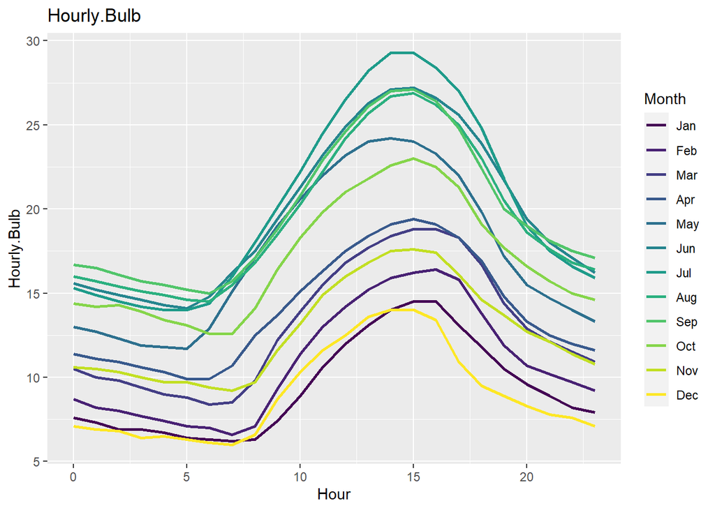

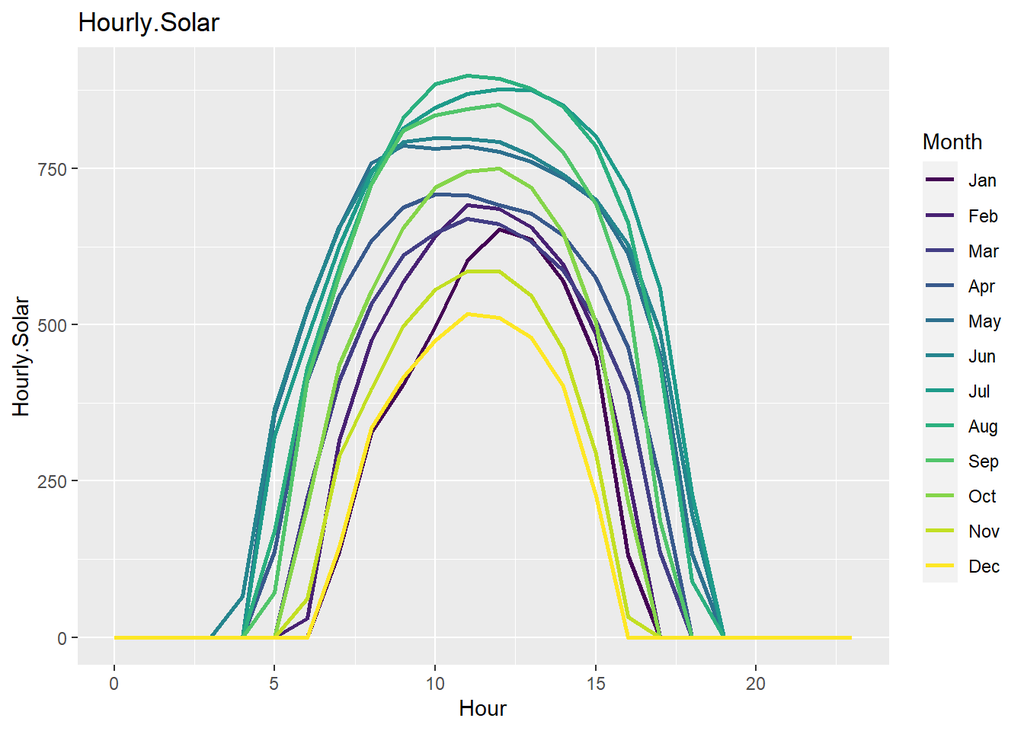

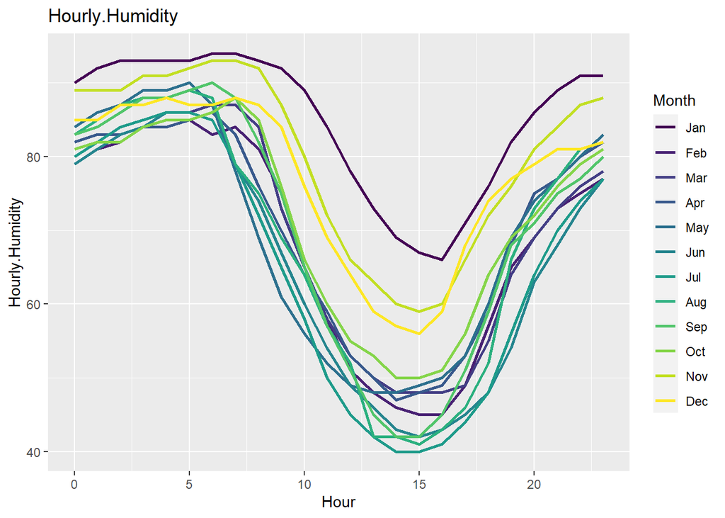

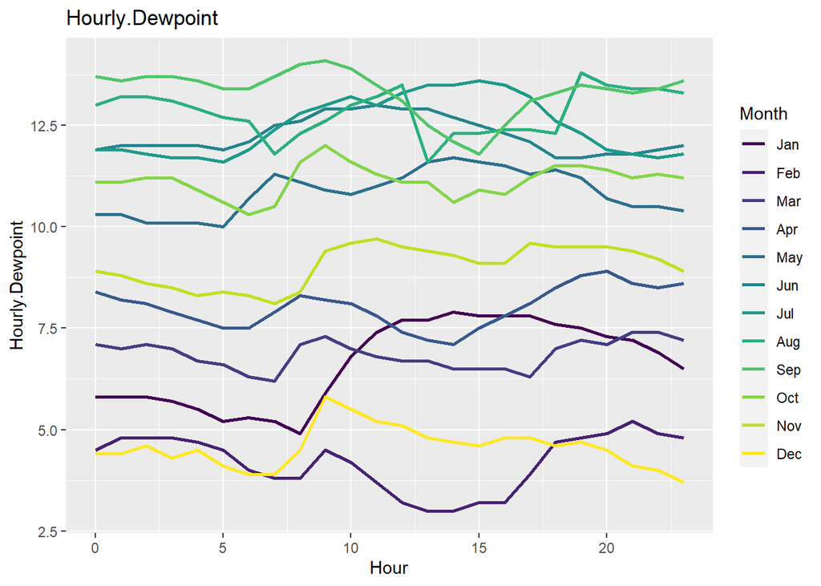

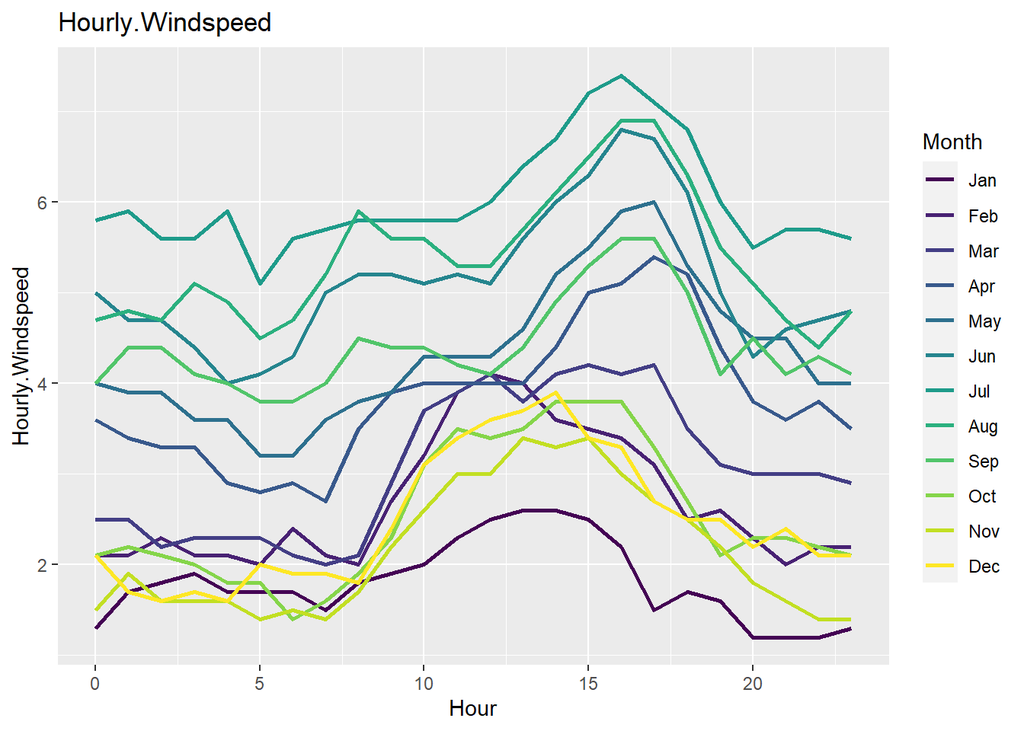

```r
library(ggplot2)
create_plots <- function(combined_table) {

#Each plot will be the same. We use the Hour as the x axis, the value for the y-axis, and color according to the month.
g1 <- ggplot(combined_table, aes(x = Hour, y = Hourly.Bulb, color = Month)) +
  geom_line(linewidth = 1) + ggtitle("Hourly.Bulb")

g2 <- ggplot(combined_table, aes(x = Hour, y = Hourly.Solar, color = Month)) +
  geom_line(linewidth = 1) + ggtitle("Hourly.Solar")

g3 <- ggplot(combined_table, aes(x = Hour, y = Hourly.Humidity, color = Month)) +
  geom_line(linewidth = 1) + ggtitle("Hourly.Humidity")

g4 <- ggplot(combined_table, aes(x = Hour, y = Hourly.Dewpoint, color = Month)) +
  geom_line(linewidth = 1) +   ggtitle("Hourly.Dewpoint")

g5 <- ggplot(combined_table, aes(x = Hour, y = Hourly.Windspeed, color = Month)) +
 geom_line(linewidth = 1) +   ggtitle("Hourly.Windspeed")

print(g1)
print(g2)
print(g3)
print(g4)
print(g5)
}


create_plots(combined_table)
```

From this first dataset from the San Francisco-Fairfield region, we can see some general trends in the graphs that occur yearlong.

The Solar graph follows a parabolic curve. When you consider that this is time series data, it makes perfect sense! There is no sun out very early in the morning or late at night. It is interesting to see how much later the sun is out in the summer months compared to the winter months. Due to a larger amount of clouds in the Winter months, there is even less solar energy than normal, even at peak daytime hours.

The humidity graph shows us that it is lowest mid-day (3 PM) and higher during the nighttime. Humidity is also highest during the winter months, with January having a much higher amount than most other months.

The dewpoint graph is the first of our bunch that does not follow a general pattern of change throughout a day. Seemingly more determined by month rather than hour of the day, the dewpoint temperature level is relatively constant for the month. Summer months have higher dewpoint temperatures while winter months have noticeably lower temperatures.

Windspeeds tend to peak between 3 - 5 PM and are higher during the Summer months. This is surprising to me. I am curious as to why this is the case, but I figure more data and research would be needed to figure out this correlation.

### Stat Table Building Complete Function

Here, we will combine most of our past functions into a mega-function that generates all of the hourly and monthly table data and applies the necessary transformations.

```r
stat_transformation_process <- function(path) {

hourly_bulb <- stat_table(start_name = "Average Hourly Statistics for Dry Bulb temperatures", type = "hourly", path = path)
hourly_dewpoint <- stat_table(start_name = "Average Hourly Statistics for Dew Point temperatures", type = "hourly", path = path)
hourly_humidity <- stat_table(start_name = "Average Hourly Relative Humidity", type = "hourly", path = path)
hourly_solar <- stat_table(start_name = "Average Hourly Statistics for Direct Normal Solar Radiation", type = "hourly", path = path)
hourly_windspeed <- stat_table(start_name = "Average Hourly Statistics for Wind Speed", type = "hourly", path = path)

monthly_wind <- stat_table(start_name = "Monthly Wind Direction", end_name = "NNW", colname = "Direction", path = path)
monthly_drybulb <- stat_table(start_name = "Monthly Statistics for Dry Bulb temperatures", end_name = "NightTime Avg" , path = path)
monthly_dewpoint <- stat_table(start_name = "Monthly Statistics for Dew Point temperatures", path = path)
monthly_windspeed <- stat_table(start_name = "Monthly Statistics for Wind Speed", path = path)


monthly_dewpoint <- monthly_transformations(monthly_dewpoint)
head(monthly_dewpoint)
monthly_drybulb <- monthly_transformations(monthly_drybulb)
head(monthly_drybulb)
monthly_windspeed <- monthly_transformations(monthly_windspeed)
head(monthly_windspeed)
monthly_wind <- monthly_transformations(monthly_wind)
head(monthly_wind)

hourly_bulb <- hourly_transformation(hourly_bulb)
hourly_windspeed <- hourly_transformation(hourly_windspeed)
hourly_dewpoint <- hourly_transformation(hourly_dewpoint)
hourly_solar <- hourly_transformation(hourly_solar)
hourly_humidity <- hourly_transformation(hourly_humidity)

data_validation(hourly_bulb)
data_validation(hourly_windspeed)
data_validation(hourly_dewpoint)
data_validation(hourly_solar)
data_validation(hourly_humidity)

combined_table <- join_tables(hourly_bulb, hourly_dewpoint, hourly_solar, hourly_windspeed, hourly_humidity)

create_plots(combined_table)
}
```

#### Davis Stat Tables

```r
path_davis = "C:/Users/HP/Documents/141BProject1Files/USA_CA_UC-Davis-University.AP.720576_TMYx.2007-2021.stat"
davis_stat <- stat_transformation_process(path_davis)
```

```
## [1] "All min hour values match"
## [1] "All max hour values match"
## [1] "All min hour values match"
## [1] "All max hour values match"
## [1] "All min hour values match"
## [1] "All max hour values match"
## [1] "All min hour values match"
## [1] "All max hour values match"
## [1] "All min hour values match"
## [1] "All max hour values match"
## [1] 288   3
## tibble [288 × 3] (S3: tbl_df/tbl/data.frame)
##  $ Hour : int [1:288] 0 1 2 3 4 5 6 7 8 9 ...
##  $ Month: Ord.factor w/ 12 levels "Jan"<"Feb"<"Mar"<..: 1 1 1 1 1 1 1 1 1 1 ...
##  $ Value: num [1:288] 8.1 7.7 7.6 7.3 7.3 7.2 7 7 7 8.5 ...
```

[output cut: 30 more lines]

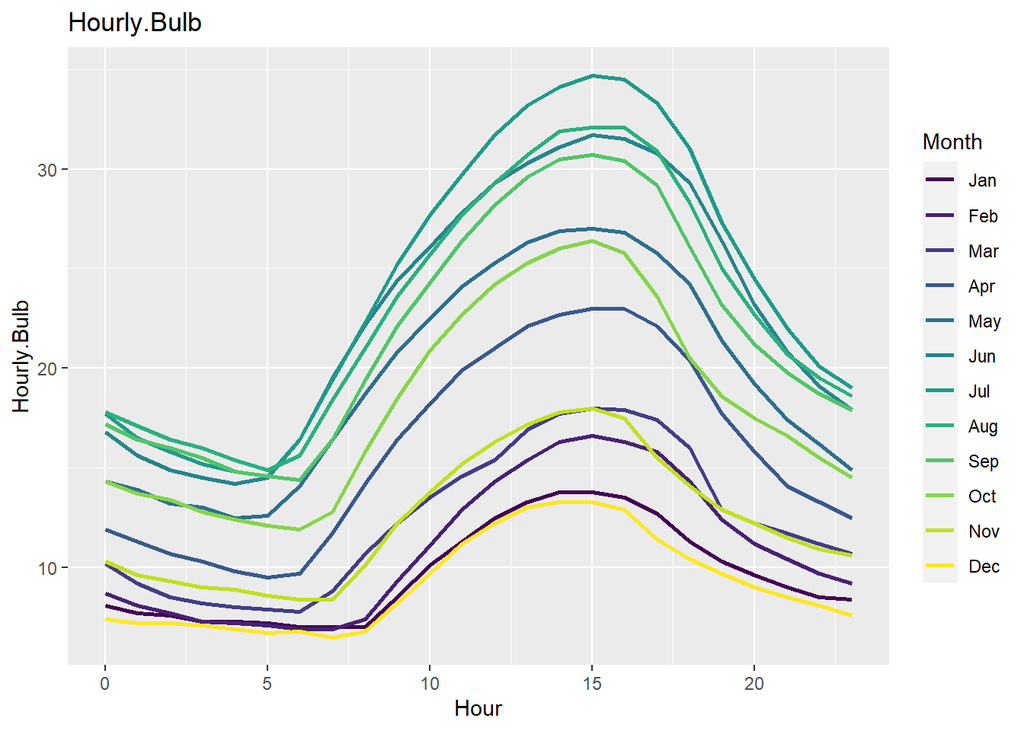

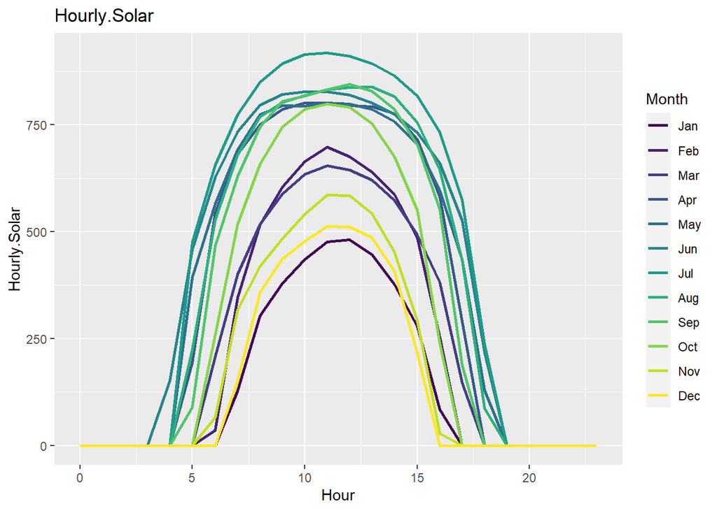

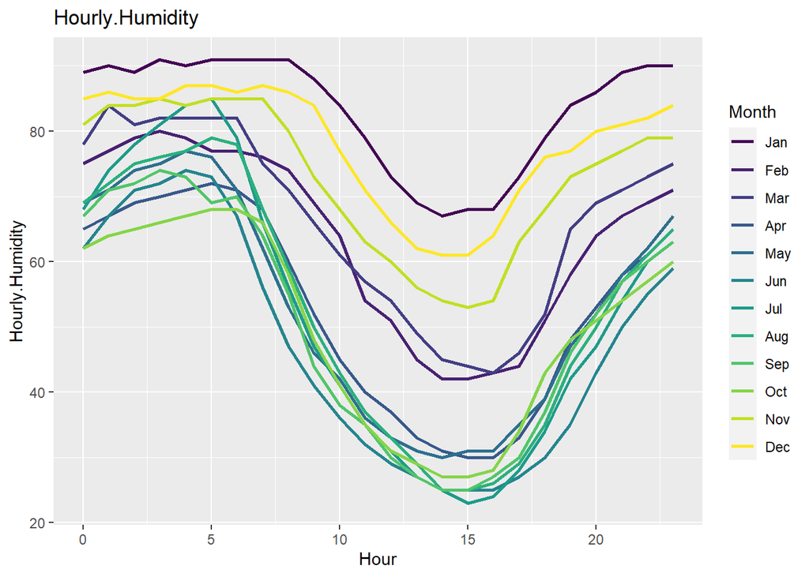

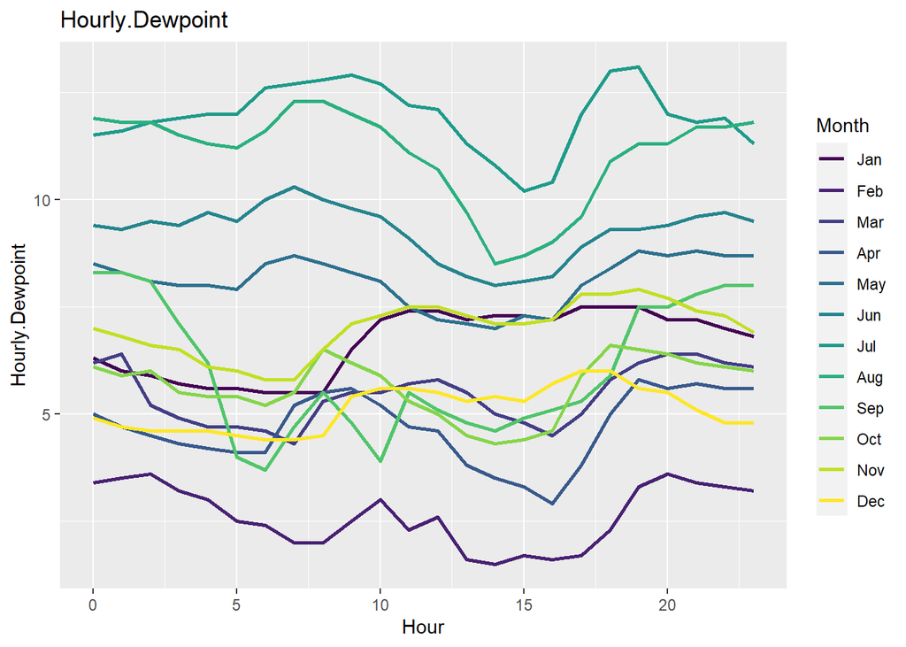

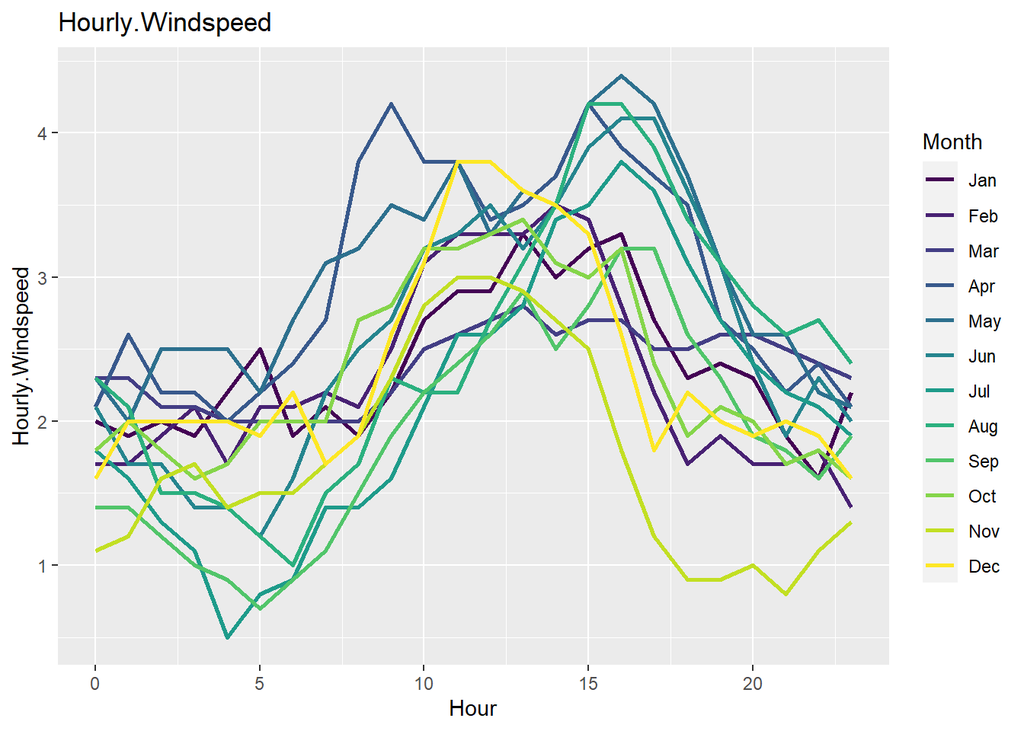

Let’s look at some general trends from Davis.

The Solar graph follows a parabolic curve. Since there is no sun out very early in the morning or late at night, it peaks at around 11am-Noon. Due to a larger amount of clouds in the Winter months, there is even less solar energy than normal, even at peak daytime hours. I’m not surprised by this given how cloudy and rainy it gets here in the winter time.

The humidity graph shows us that it is lowest mid-day (3 PM) and higher during the nighttime. Humidity is also highest during the winter months, with January having a much higher amount than most other months. Truthfully, it never feels all that humid in Davis.

The dewpoint graph is the first of our bunch that does not follow a general pattern of change throughout a day. Seemingly more determined by month rather than hour of the day, the dewpoint temperature level is relatively constant for the month. Summer months have higher dewpoint temperatures while winter months have noticeably lower temperatures.

#### Point Reyes Stat Tables

```r
path_point_reyes = "C:/Users/HP/Documents/141BProject1Files/USA_CA_Point.Reyes.Lighthouse.724959_TMYx.2007-2021.stat"
point_reyes_stat <- stat_transformation_process(path_point_reyes)
```

```
## [1] "All min hour values match"
## [1] "All max hour values match"
## [1] "All min hour values match"
## [1] "All max hour values match"
## [1] "All min hour values match"
## [1] "All max hour values match"
## [1] "All min hour values match"
## [1] "All max hour values match"
## [1] "All min hour values match"
## [1] "All max hour values match"
## [1] 288   3
## tibble [288 × 3] (S3: tbl_df/tbl/data.frame)
##  $ Hour : int [1:288] 0 1 2 3 4 5 6 7 8 9 ...
##  $ Month: Ord.factor w/ 12 levels "Jan"<"Feb"<"Mar"<..: 1 1 1 1 1 1 1 1 1 1 ...
##  $ Value: num [1:288] 11.6 11.4 11.4 11.4 11.4 11.2 11.2 11.1 11.1 11.7 ...
```

[output cut: 30 more lines]

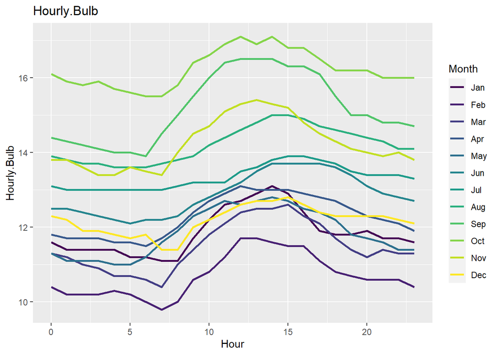

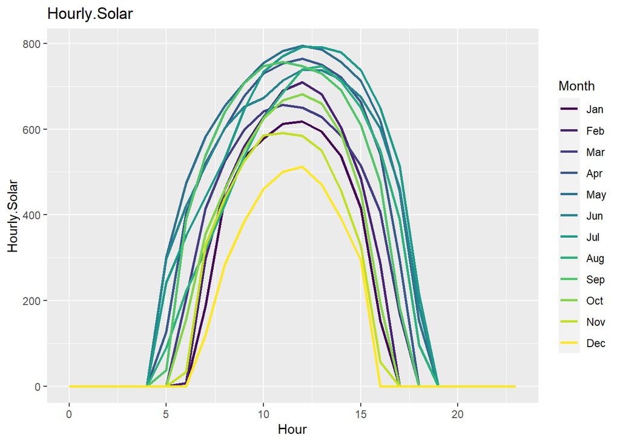

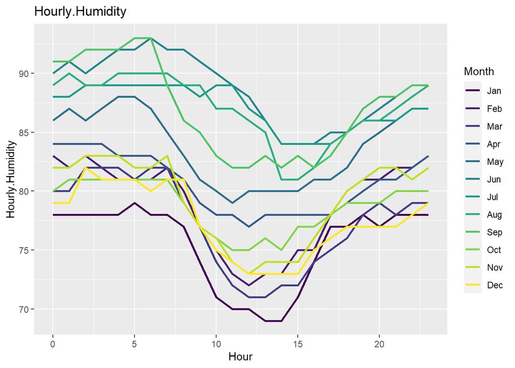

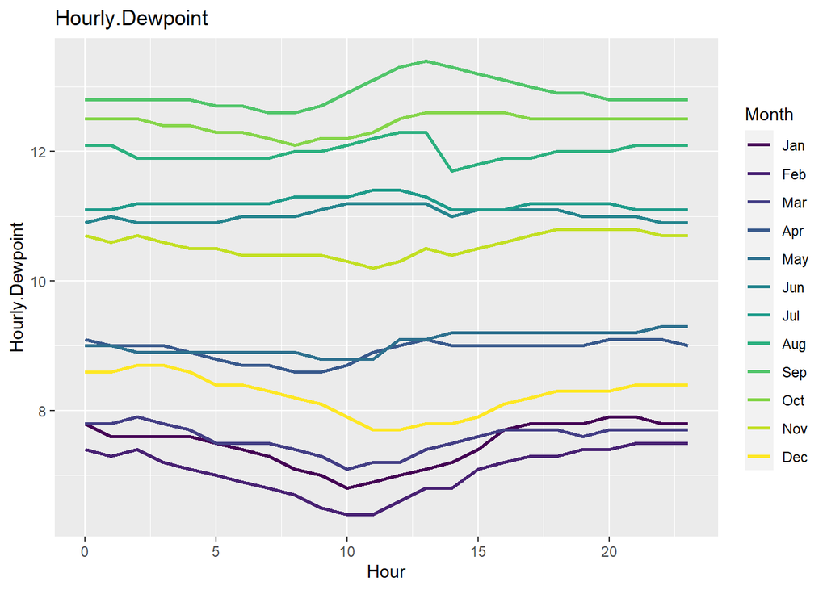

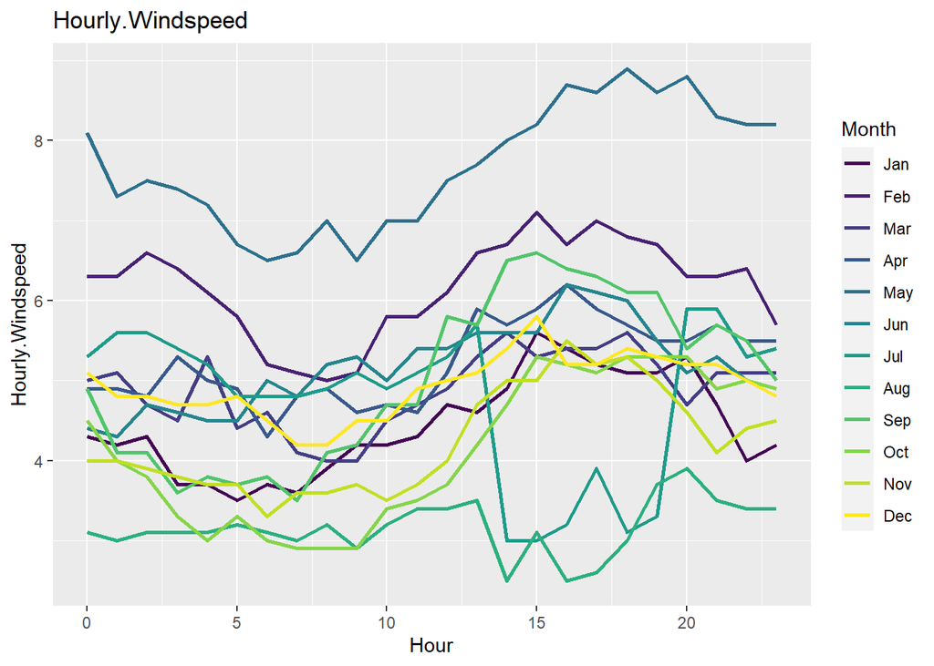

It’s humidity values display much less consistency than Davis or SF-Fairfield. Rather than a relatively uniform curve, there are many more peaks and troughs throughout the plots. Its humidity is also much higher in the Summer than the Winter, which is inverse to Davis and SF-Fairfield. It also exhibits higher peaks overall.

Dewpoint values are much more consistent. They tend to follow very similar grouping bands and values stay consistent throughout the day. Summer reigns supreme over Winter here as well, which is the trend across all three graphs.

Lastly, Point Reyes’ windspeed graph is much more erratic than Davis’s, without much of a general pattern. In addition, it reaches up to 8 mph in June, nearly double the maximum of Davis.

#### Napa Stat Tables

```r
path_napa = "C:/Users/HP/Documents/141BProject1Files/USA_CA_Napa.County.AP.724955_TMYx.2007-2021.stat"
napa_stat <- stat_transformation_process(path_napa)
```

```
## [1] "All min hour values match"
## [1] "All max hour values match"
## [1] "All min hour values match"
## [1] "All max hour values match"
## [1] "All min hour values match"
## [1] "All max hour values match"
## [1] "All min hour values match"
## [1] "All max hour values match"
## [1] "All min hour values match"
## [1] "All max hour values match"
## [1] 288   3
## tibble [288 × 3] (S3: tbl_df/tbl/data.frame)
##  $ Hour : int [1:288] 0 1 2 3 4 5 6 7 8 9 ...
##  $ Month: Ord.factor w/ 12 levels "Jan"<"Feb"<"Mar"<..: 1 1 1 1 1 1 1 1 1 1 ...
##  $ Value: num [1:288] 7.7 7.6 7 6.8 6.6 6.6 6.3 6.5 8 9.8 ...
```

[output cut: 30 more lines]

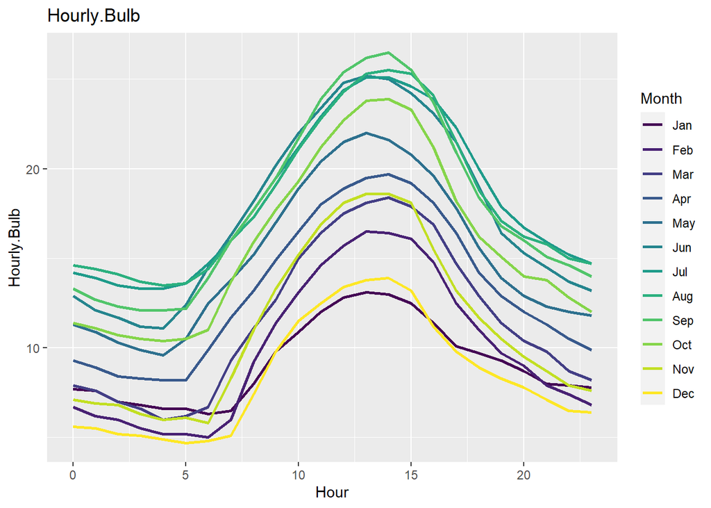

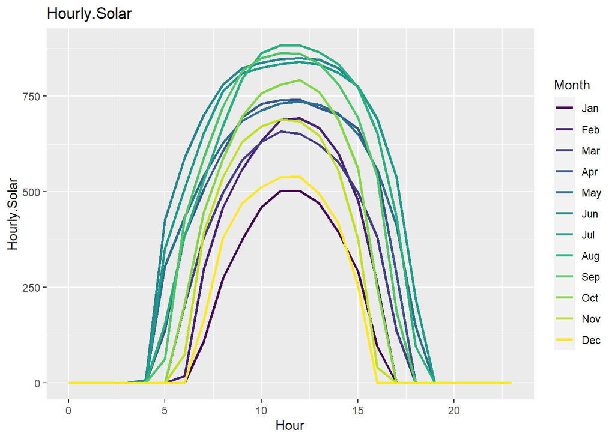

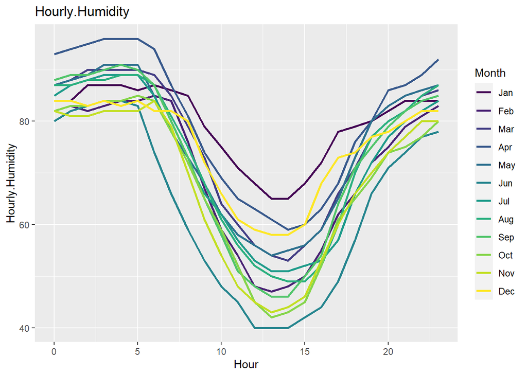

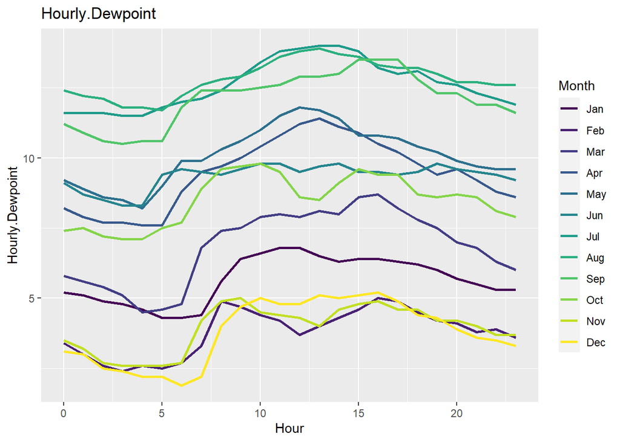

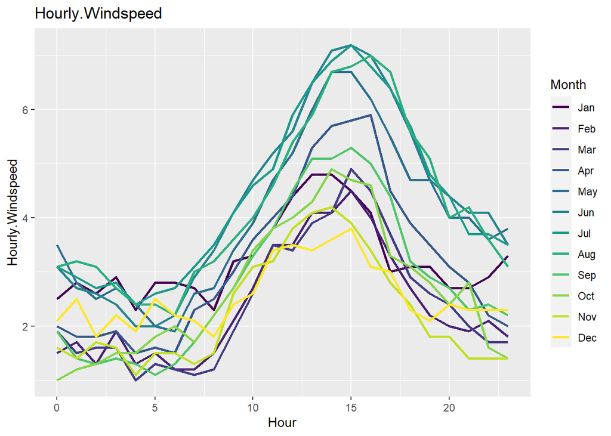

Let’s look at the Napa charts.

For the bulb, solar, and humidity graphs, it displays uniform curves, similar to Davis and Fairfield-SF.

Its dewpoint values display the consistent bands similar to Point Reyes, but more up-and-down movement like the first two data groups.

Its windspeed graph follows a very concise curve throughout all seasons, peaking at 3 PM each day. Napa also has very high windspeeds, reaching to 7 MPH in the summer months.

#### Marin Stat Tables

```r
path_marin = "C:/Users/HP/Documents/141BProject1Files/USA_CA_Marin.County.AP-Gnoss.Field.720406_TMYx.2007-2021.stat"

marin_stat <- stat_transformation_process(path_marin)
```

```
## [1] "All min hour values match"
## [1] "All max hour values match"
## [1] "All min hour values match"
## [1] "All max hour values match"
## [1] "All min hour values match"
## [1] "All max hour values match"
## [1] "All min hour values match"
## [1] "All max hour values match"
## [1] "All min hour values match"
## [1] "All max hour values match"
## [1] 288   3
## tibble [288 × 3] (S3: tbl_df/tbl/data.frame)
##  $ Hour : int [1:288] 0 1 2 3 4 5 6 7 8 9 ...
##  $ Month: Ord.factor w/ 12 levels "Jan"<"Feb"<"Mar"<..: 1 1 1 1 1 1 1 1 1 1 ...
##  $ Value: num [1:288] 7.1 7 6.7 6.5 6.2 6 6 6.1 7.1 8.9 ...
```

[output cut: 30 more lines]

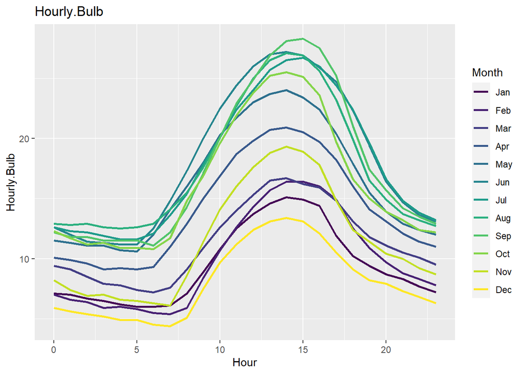

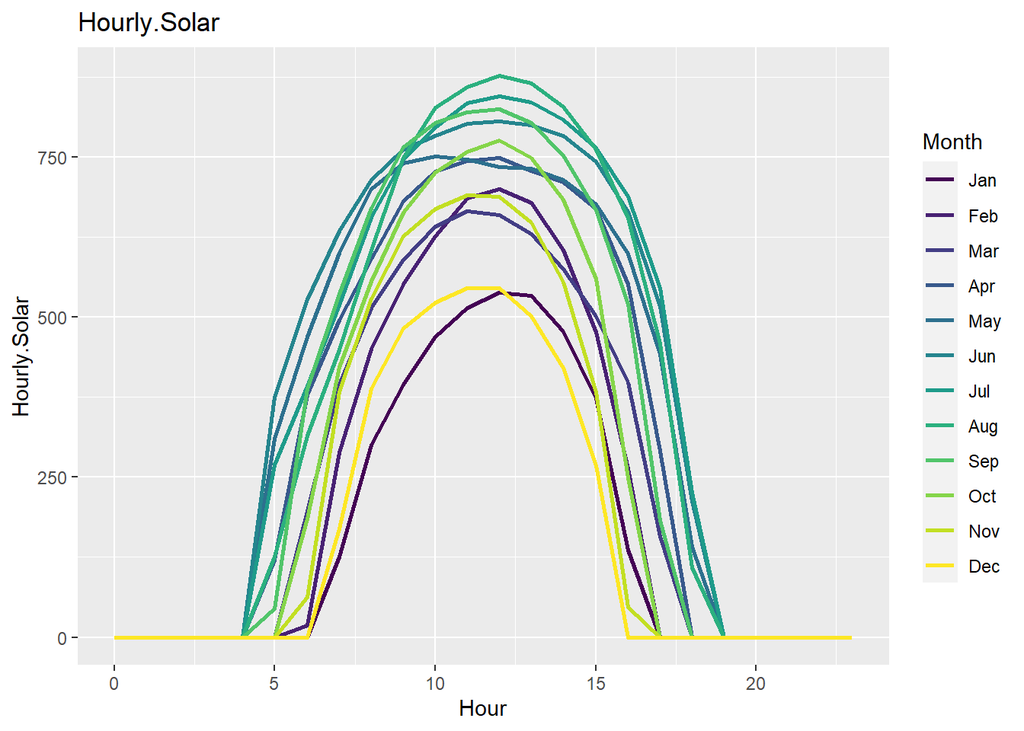

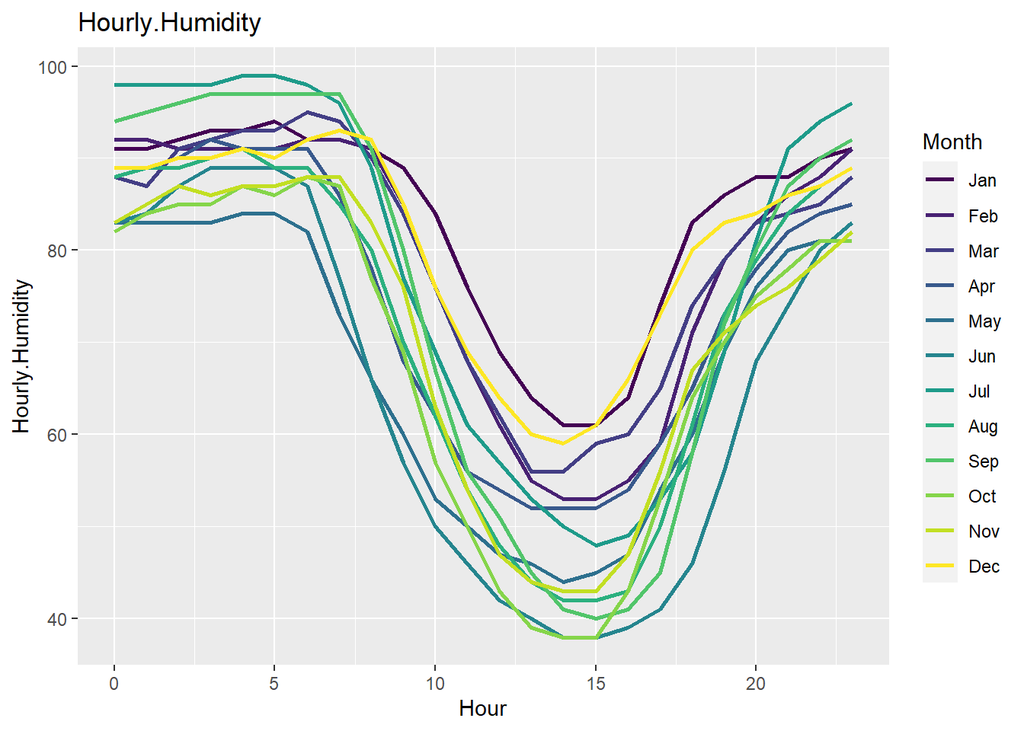

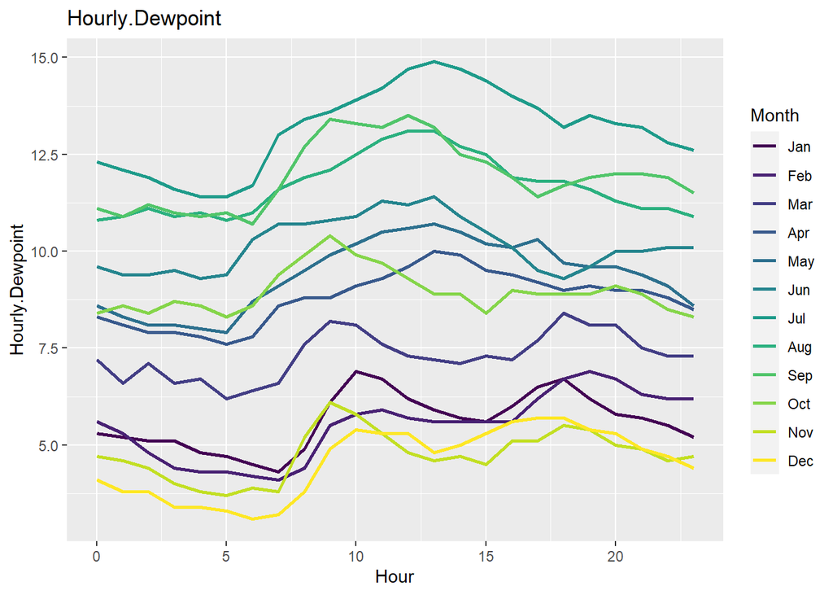

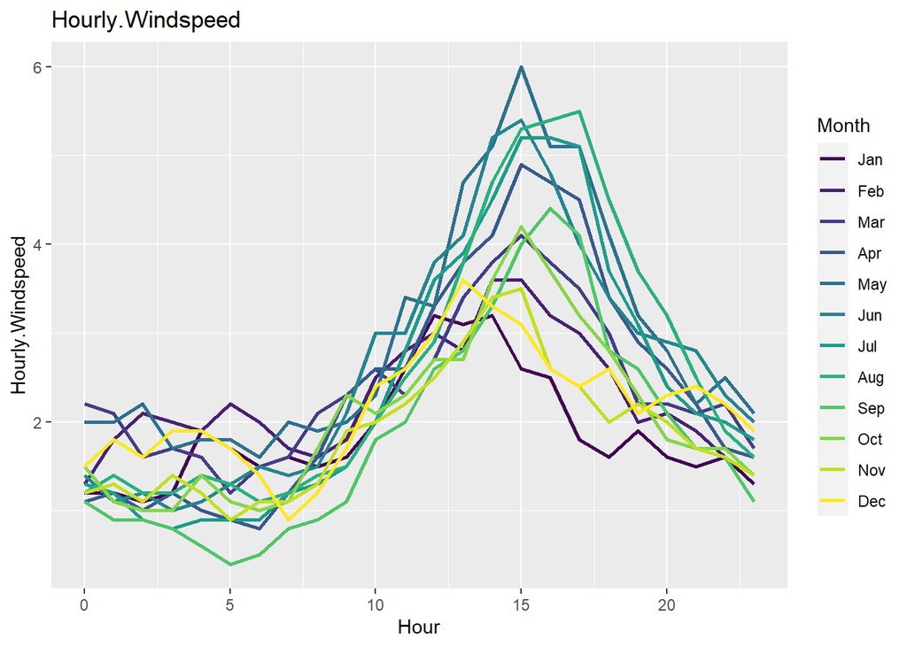

Marin’s bulb graph is almost identical to Napa’s. It peaks at around the same time and exhibits higher temperatures in the summer (as to be expected).

The solar graph has a very similar parabolic curve to all other datasets.

Humidity also has a very similar structure to all except Point Reyes. Noticeably, it does peak very high during the summer months, clocking in at around 100. Once the sun rises, it declines greatly in the summer. At 3 PM, the inversion point of the graph, the winter graphs are the highest.

Dewpoint also follows the trend of the other graphs, with summer months boasting a noticeably higher temperature than the winter months.

Windspeed has a very uniform curve, peaking around 3 PM. The summer months reach up to 6 MPH, which places it around the middle of the overall distribution.

# Conclusion

After reading in many tables, validating, transforming, and plotting the data, we are able to get some basic insights about the general topography and climate of five northern california regions.

While many of them follow similar trends and curves across days and months, there are some very interesting differences and quirks for each region. For example, inverse to the other regions, Point Reyes’ has the highest humidity levels during the summer.

This was a great exercise in order to familiarize oneself with the basics of R and how to take command of data, no matter how archaic the format is.